# Informe ejecutivo: comparación entre participante 1 y referencia

## 1 Resumen ejecutivo

Este informe compara las mediciones de `p1` contra la `referencia` en los archivos `data/processed/ronda_1_completa.csv` y `data/processed/ronda_2_completa.csv`.

El análisis se hizo sobre pares coincidentes por `pollutant`, `level` y `run`. Se reportan:

- prueba T pareada sobre `mean_value`
- ANOVA de una vía sobre `mean_value` con factor `grupo`

Como solo hay dos grupos, el ANOVA y la prueba T evalúan la misma diferencia principal.

## 2 Resultado global

Resumen global de la comparación pareada

| N pares | Promedio p1 | Promedio referencia | Diferencia media | t | gl | p valor T | IC 95% inf. | IC 95% sup. | F | p valor ANOVA |
| --- | --- | --- | --- | --- | --- | --- | --- | --- | --- | --- |
| 25 | 64.831 | 64.416 | 0.416 | 0.84 | 24 | 0.409 | -0.606 | 1.438 | 0.001 | 0.982 |

## 3 Normalidad de las diferencias

La prueba de normalidad se aplica a las diferencias pareadas `p1 - referencia`.

Prueba de Shapiro-Wilk sobre las diferencias pareadas

| W | p valor | N |
| --- | --- | --- |
| 0.943 | 0.175 | 25 |

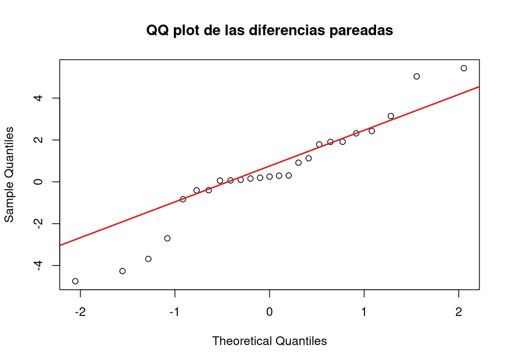

Interpretación:

- Si `p valor > 0.05`, no hay evidencia suficiente para rechazar normalidad.
- Si `p valor <= 0.05`, la normalidad de las diferencias es cuestionable.

Interpretación ejecutiva:

- Si el `p valor T` y el `p valor ANOVA` son menores que 0.05, hay evidencia de diferencia sistemática entre `p1` y la referencia.
- La columna `Diferencia media` se interpreta como `p1 - referencia`.
- Valores positivos indican que `p1` tiende a medir por encima de la referencia.

## 4 Resultado por ronda

Pruebas por ronda

| Ronda | t | gl | p valor T | Diferencia media | IC 95% inf. | IC 95% sup. | F | p valor ANOVA |
| --- | --- | --- | --- | --- | --- | --- | --- | --- |
| Ronda 1 | 1.831 | 9 | 0.100 | 0.994 | -0.234 | 2.223 | 0.001 | 0.973 |
| Ronda 2 | 0.041 | 14 | 0.968 | 0.030 | -1.557 | 1.617 | 0.000 | 0.999 |

Promedios por ronda

| Ronda | N pares | Promedio p1 | Promedio referencia | Diferencia media | Diferencia mediana |
| --- | --- | --- | --- | --- | --- |
| Ronda 1 | 10 | 44.531 | 43.537 | 0.994 | 0.245 |
| Ronda 2 | 15 | 78.365 | 78.335 | 0.030 | 0.249 |

## 5 Diferencias por contaminante

Brecha media por contaminante

| Ronda | Contaminante | N | Diferencia media | DE de la diferencia |
| --- | --- | --- | --- | --- |
| Ronda 1 | co | 5 | 0.116 | 0.059 |
| Ronda 1 | so2 | 5 | 1.872 | 2.169 |
| Ronda 2 | no | 5 | 2.078 | 2.196 |
| Ronda 2 | no2 | 5 | -3.158 | 1.720 |
| Ronda 2 | o3 | 5 | 1.171 | 1.179 |

## 6 Resultado por nivel

Los niveles con `n < 2` no permiten una prueba T pareada válida, por lo que se reportan como no evaluables.

Comparación agregada por nivel

| Nivel | N pares | Diferencia media | t | p valor |
| --- | --- | --- | --- | --- |
| 0-nmol/mol | 4 | -0.170 | -0.624 | 0.5770 |
| 0-µmol/mol | 1 | 0.059 | NA | NA |
| 1.4-µmol/mol | 1 | 0.069 | NA | NA |
| 105-nmol/mol | 1 | -3.683 | NA | NA |
| 119-nmol/mol | 2 | 2.785 | 7.745 | 0.0817 |
| 120-nmol/mol | 1 | 1.787 | NA | NA |
| 140-nmol/mol | 1 | -2.700 | NA | NA |
| 179-nmol/mol | 1 | 5.427 | NA | NA |
| 180-nmol/mol | 2 | 2.316 | 0.851 | 0.5510 |
| 2.8-µmol/mol | 1 | 0.098 | NA | NA |
| 30-nmol/mol | 1 | -4.261 | NA | NA |
| 37-nmol/mol | 1 | 1.124 | NA | NA |
| 4.2-µmol/mol | 1 | 0.158 | NA | NA |
| 40-nmol/mol | 2 | 1.305 | 1.291 | 0.4200 |
| 6.3-µmol/mol | 1 | 0.196 | NA | NA |
| 60-nmol/mol | 1 | -4.748 | NA | NA |
| 78-nmol/mol | 1 | 1.915 | NA | NA |
| 80-nmol/mol | 2 | 1.410 | 2.837 | 0.2160 |

Comparación por ronda y nivel

| Ronda | Nivel | N pares | Diferencia media | t | p valor |
| --- | --- | --- | --- | --- | --- |
| Ronda 1 | 0-nmol/mol | 1 | 0.303 | NA | NA |
| Ronda 1 | 0-µmol/mol | 1 | 0.059 | NA | NA |
| Ronda 1 | 1.4-µmol/mol | 1 | 0.069 | NA | NA |
| Ronda 1 | 119-nmol/mol | 1 | 2.425 | NA | NA |
| Ronda 1 | 179-nmol/mol | 1 | 5.427 | NA | NA |
| Ronda 1 | 2.8-µmol/mol | 1 | 0.098 | NA | NA |
| Ronda 1 | 4.2-µmol/mol | 1 | 0.158 | NA | NA |
| Ronda 1 | 40-nmol/mol | 1 | 0.294 | NA | NA |
| Ronda 1 | 6.3-µmol/mol | 1 | 0.196 | NA | NA |
| Ronda 1 | 80-nmol/mol | 1 | 0.913 | NA | NA |
| Ronda 2 | 0-nmol/mol | 3 | -0.327 | -1.043 | 0.407 |
| Ronda 2 | 105-nmol/mol | 1 | -3.683 | NA | NA |
| Ronda 2 | 119-nmol/mol | 1 | 3.144 | NA | NA |
| Ronda 2 | 120-nmol/mol | 1 | 1.787 | NA | NA |
| Ronda 2 | 140-nmol/mol | 1 | -2.700 | NA | NA |
| Ronda 2 | 180-nmol/mol | 2 | 2.316 | 0.851 | 0.551 |
| Ronda 2 | 30-nmol/mol | 1 | -4.261 | NA | NA |
| Ronda 2 | 37-nmol/mol | 1 | 1.124 | NA | NA |
| Ronda 2 | 40-nmol/mol | 1 | 2.315 | NA | NA |
| Ronda 2 | 60-nmol/mol | 1 | -4.748 | NA | NA |
| Ronda 2 | 78-nmol/mol | 1 | 1.915 | NA | NA |
| Ronda 2 | 80-nmol/mol | 1 | 1.907 | NA | NA |

```
## Niveles no evaluables por tener menos de dos pares:  0-µmol/mol, 1.4-µmol/mol, 105-nmol/mol, 120-nmol/mol, 140-nmol/mol, 179-nmol/mol, 2.8-µmol/mol, 30-nmol/mol, 37-nmol/mol, 4.2-µmol/mol, 6.3-µmol/mol, 60-nmol/mol, 78-nmol/mol
```

## 7 Visualización rápida

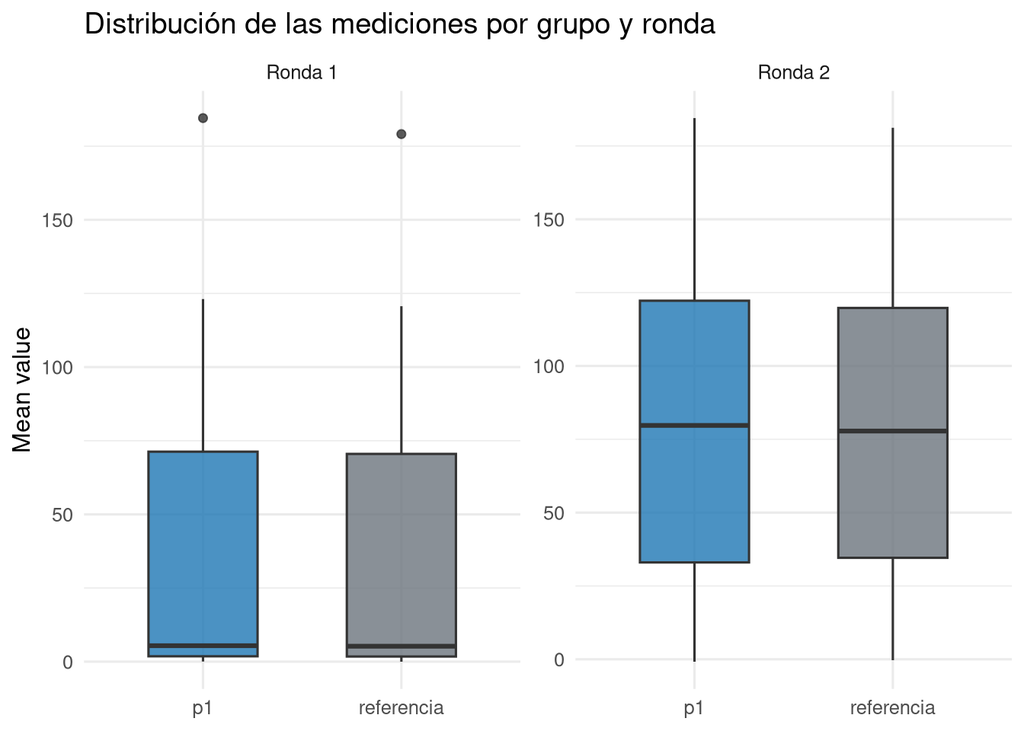

## 8 Conclusión

No se observan diferencias estadísticamente significativas entre `p1` y la referencia ni en el análisis global ni en el corte por nivel. El nivel más cercano a significancia fue `119-nmol/mol`, pero no cruzó el umbral de 0.05. Los niveles con una sola observación emparejada no son evaluables con prueba T pareada.